# Time Series Analysis - Effect of Economic Crisis

Sneha Vasanth, Janani Kumar, Tigh Bradley, Gaurav Gada

February 21, 2017

Github link: https://github.com/snehavcs/Data-Science-I-Project

Are there obvious trends in the data (over time, across subgroups, etc.), and are the differences statistically significant?

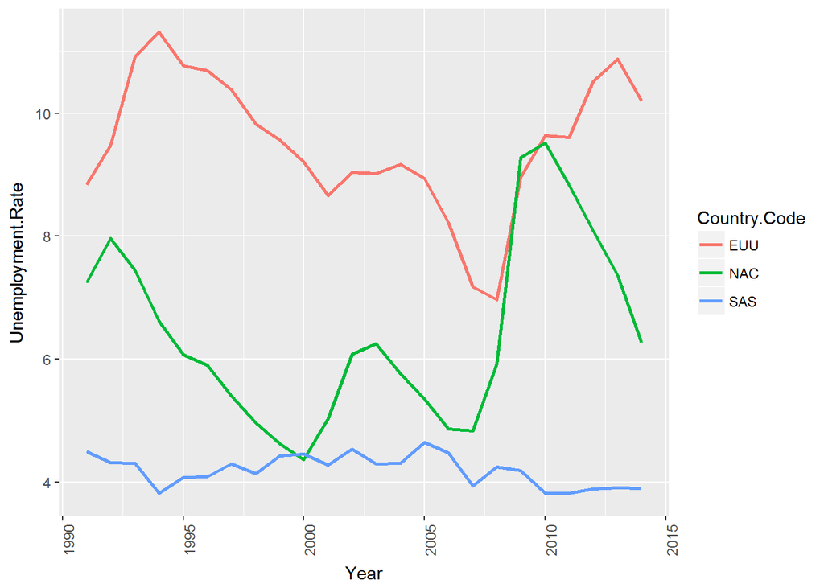

```r
region_data <- read.csv("region_data.csv")
unemp_compare <- region_data %>%
  select(Country.Name,Country.Code,Year,Unemployment.Rate,Time_Period) %>%
  filter(Year >= 1991 & Year<= 2014 & (Country.Code =='EUU'| Country.Code == 'SAS' | Country.Code == 'NAC')) %>%
  group_by(Year)

ggplot(unemp_compare,aes(x = Year, y = Unemployment.Rate, col = Country.Code, group = Country.Code)) +geom_line(na.rm = T,lwd = 1)+ theme(axis.text.x=element_text(angle=90, hjust=1))
```

There is a steep increase in the uemployment rates of North America and Europe while South Asia is comparitively stable post the 2008 recession.

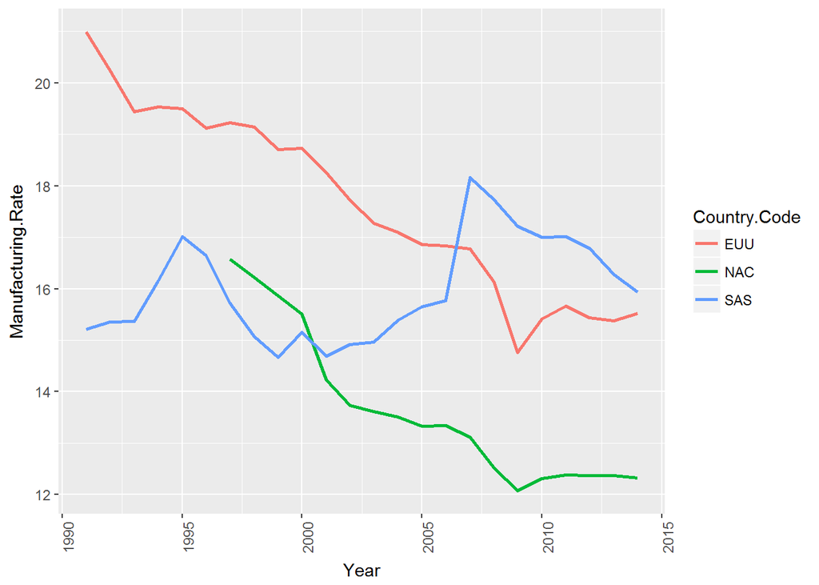

```r
manufacturing_compare <- region_data %>%
  select(Country.Name,Country.Code,Year,Manufacturing.Rate) %>%
  filter(Year >= 1991 & Year<= 2014 & (Country.Code =='EUU'| Country.Code == 'SAS' | Country.Code == 'NAC')) %>%
  group_by(Year)

ggplot(manufacturing_compare,aes(x = Year, y = Manufacturing.Rate, col = Country.Code, group = Country.Code)) +geom_line(na.rm = T,lwd = 1)+ theme(axis.text.x=element_text(angle=90, hjust=1))
```

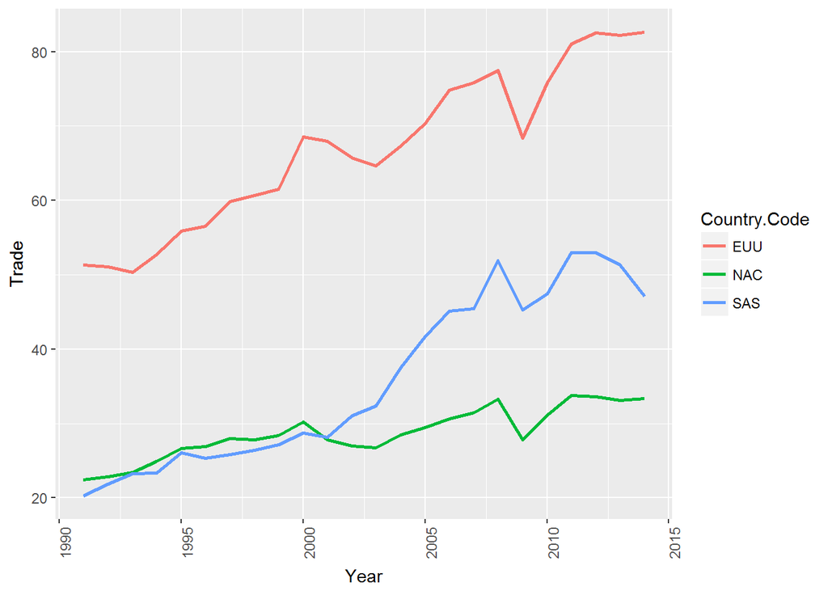

```r
trade_compare <- region_data %>%
  select(Country.Name,Country.Code,Year,Trade) %>%
  filter(Year >= 1991 & Year<= 2014 & (Country.Code =='EUU'| Country.Code == 'SAS' | Country.Code == 'NAC')) %>%
  group_by(Year)

ggplot(trade_compare,aes(x = Year, y = Trade, col = Country.Code, group = Country.Code)) +geom_line(na.rm = T,lwd = 1)+ theme(axis.text.x=element_text(angle=90, hjust=1))
```

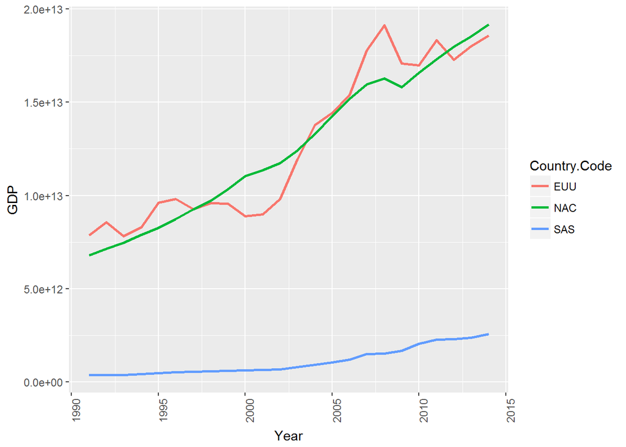

```r
gdp_compare <- region_data %>%
  select(Country.Name,Country.Code,Year,GDP) %>%
  filter(Year >= 1991 & Year<= 2014 & (Country.Code =='EUU'| Country.Code == 'SAS' | Country.Code == 'NAC')) %>%
  group_by(Year)

ggplot(gdp_compare,aes(x = Year, y = GDP, col = Country.Code, group = Country.Code)) +geom_line(na.rm = T,lwd = 1)+ theme(axis.text.x=element_text(angle=90, hjust=1))
```

Understanding time series implementation for CPI in USA:

```r
CPI_trend<-read.csv("CPI_World_Bank.csv")
#plot(CPI_trend$)
colnames(CPI_trend)
```

```
##  [1] "Country.Name"   "Country.Code"   "Indicator.Name" "Indicator.Code"
##  [5] "X1960"          "X1961"          "X1962"          "X1963"
##  [9] "X1964"          "X1965"          "X1966"          "X1967"
## [13] "X1968"          "X1969"          "X1970"          "X1971"
## [17] "X1972"          "X1973"          "X1974"          "X1975"
## [21] "X1976"          "X1977"          "X1978"          "X1979"
## [25] "X1980"          "X1981"          "X1982"          "X1983"
## [29] "X1984"          "X1985"          "X1986"          "X1987"
## [33] "X1988"          "X1989"          "X1990"          "X1991"
## [37] "X1992"          "X1993"          "X1994"          "X1995"
## [41] "X1996"          "X1997"          "X1998"          "X1999"
## [45] "X2000"          "X2001"          "X2002"          "X2003"
## [49] "X2004"          "X2005"          "X2006"          "X2007"
## [53] "X2008"          "X2009"          "X2010"          "X2011"
## [57] "X2012"          "X2013"          "X2014"          "X2015"
## [61] "X2016"
```

```r
#goal here is time period on x and CPI on y.
trends<-read.csv("Timeseries.csv")
class(trends)
```

```
## [1] "data.frame"
```

```r
#summary(lm(Time ~ CPI_USA, data=trends))
#plot(trends)
#abline(lsfit(x=trends$Time,y=trends$CPI_USA),col="red")
#install.packages('tseries')
require(tseries)
#install.packages('xts')
require(xts)
#converting data into time series data
trends.ts<-ts(as.vector(trends), start = c(1960,1), end = c(2015),frequency = 1)
trends.ts
```

```
## Time Series:
## Start = 1960
## End = 2015
## Frequency = 1
##         CPI_USA
##  [1,]  13.57217
##  [2,]  13.71809
##  [3,]  13.87120
##  [4,]  14.03961
##  [5,]  14.22333
##  [6,]  14.46064
##  [7,]  14.89316
##  [8,]  15.30654
##  [9,]  15.95213
## [10,]  16.81589
```

[output cut: 46 more lines]

```r
class(trends.ts)
```

```
## [1] "ts"
```

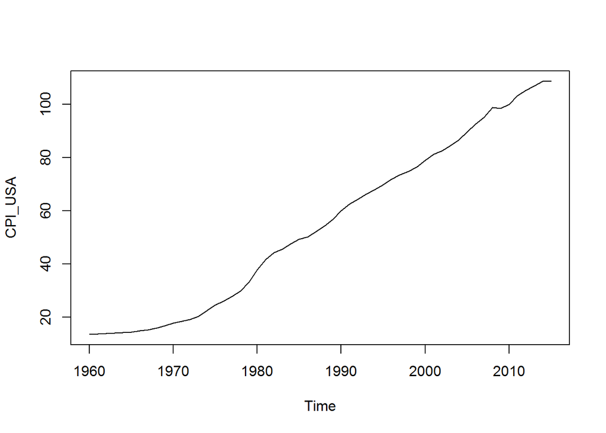

```r
plot(trends.ts)
```

```r
#Dickey-fuller test to see if the time series is stationary.
adf.test(trends.ts)
```

```
##
##  Augmented Dickey-Fuller Test
##
## data:  trends.ts
## Dickey-Fuller = -3.2846, Lag order = 3, p-value = 0.08307
## alternative hypothesis: stationary
```

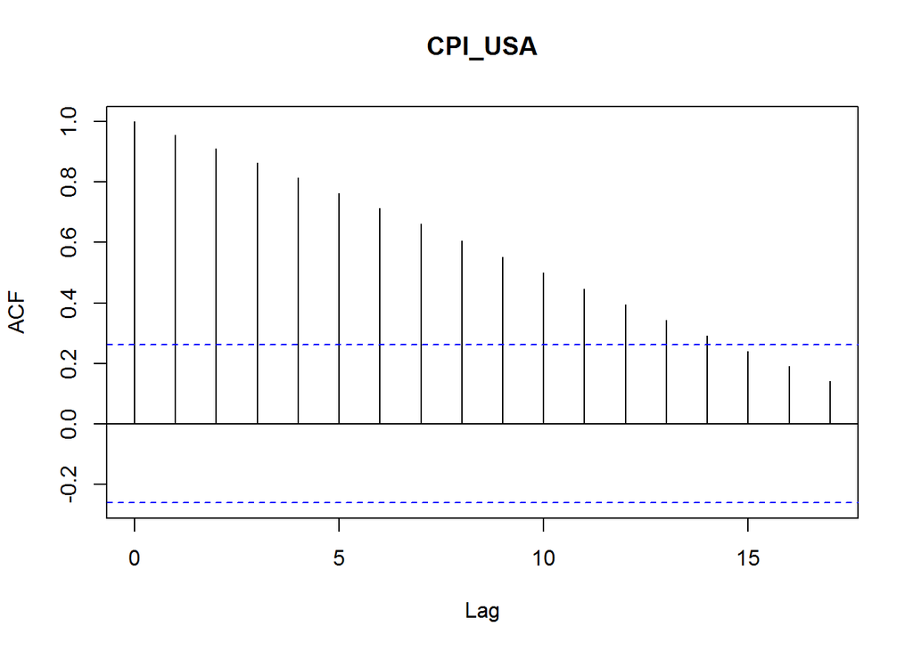

```r
#Checking for p and q values through auto correlation function and partial auto correlation function.
acf(trends.ts)
```

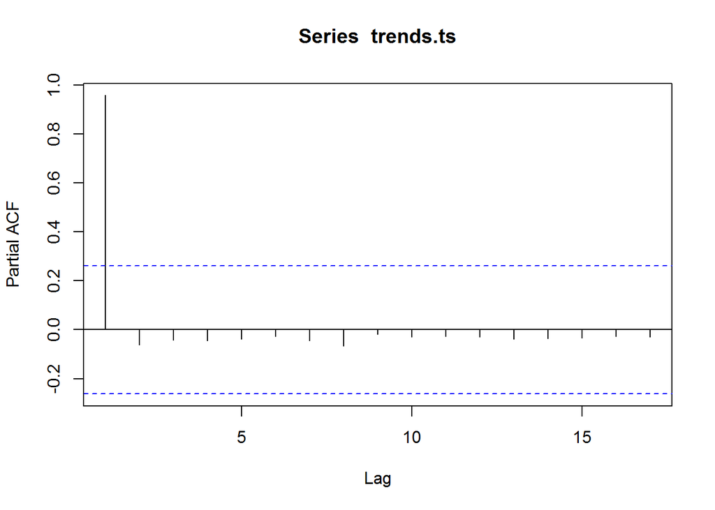

```r
pacf(trends.ts)
```

```r
#this is an AR model
#install.packages('forecast')
auto.arima(trends.ts)
```

```
## Series: trends.ts
## ARIMA(1,2,1)
##
## Coefficients:
##          ar1      ma1
##       0.4603  -0.8296
## s.e.  0.2091   0.1391
##
## sigma^2 estimated as 0.7067:  log likelihood=-66.45
## AIC=138.9   AICc=139.38   BIC=144.87
```

```r
trends.arimausa<- arima(trends.ts, order=c(1,2,1))
trends.arimausa
```

```
##
## Call:
## arima(x = trends.ts, order = c(1, 2, 1))
##
## Coefficients:
##          ar1      ma1
##       0.4603  -0.8296
## s.e.  0.2091   0.1391
##
## sigma^2 estimated as 0.6805:  log likelihood = -66.45,  aic = 138.9
```

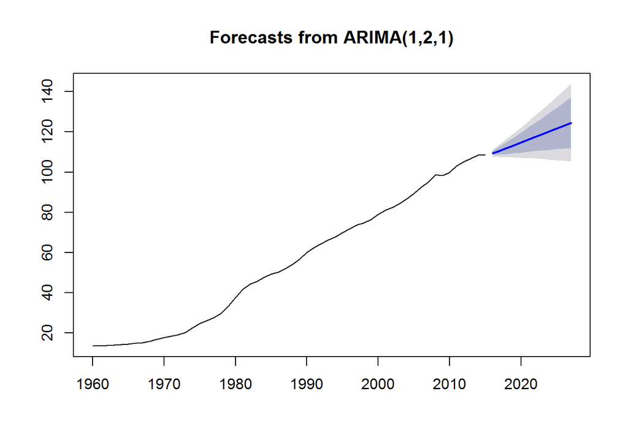

```r
trend.preds<-forecast.Arima(trends.arimausa,h=12)
plot.forecast(trend.preds)
```

```r
summary(trend.preds)
```

```
##
## Forecast method: ARIMA(1,2,1)
##
## Model Information:
##
## Call:
## arima(x = trends.ts, order = c(1, 2, 1))
##
## Coefficients:
##          ar1      ma1
##       0.4603  -0.8296
## s.e.  0.2091   0.1391
##
## sigma^2 estimated as 0.6805:  log likelihood = -66.45,  aic = 138.9
##
## Error measures:
##                      ME     RMSE       MAE       MPE     MAPE      MASE
## Training set 0.06899142 0.810064 0.5382748 0.4357933 1.112776 0.3089477
##                    ACF1
## Training set 0.02865192
##
## Forecasts:
##      Point Forecast    Lo 80    Hi 80    Lo 95    Hi 95
## 2016       109.5173 108.4601 110.5745 107.9005 111.1341
## 2017       110.6577 108.6354 112.6801 107.5648 113.7506
## 2018       111.9450 108.9485 114.9415 107.3623 116.5278
## 2019       113.2999 109.3225 117.2773 107.2169 119.3828
## 2020       114.6859 109.7148 119.6569 107.0833 122.2884
## 2021       116.0861 110.1025 122.0698 106.9349 125.2374
## 2022       117.4930 110.4728 124.5132 106.7566 128.2295
## 2023       118.9030 110.8190 126.9869 106.5396 131.2663
## 2024       120.3143 111.1373 129.4913 106.2793 134.3493
## 2025       121.7262 111.4257 132.0268 105.9729 137.4796
## 2026       123.1385 111.6832 134.5938 105.6191 140.6579
## 2027       124.5509 111.9094 137.1924 105.2174 143.8844
```

```r
#Hypothesis testing for USA CPI data
#install.packages('lmtest')
coeftest(trends.arimausa)
```

```
##
## z test of coefficients:
##
##     Estimate Std. Error z value  Pr(>|z|)
## ar1  0.46035    0.20911  2.2014   0.02771 *
## ma1 -0.82959    0.13908 -5.9649 2.447e-09 ***
## ---
## Signif. codes:  0 '***' 0.001 '**' 0.01 '*' 0.05 '.' 0.1 ' ' 1
```

```r
#z value is 2.2014, p=0.02771
#another way to obtain p value to verify
(1-pnorm(abs(trends.arimausa$coef)/sqrt(diag(trends.arimausa$var.coef))))*2
```

```
##          ar1          ma1
## 2.770520e-02 2.447359e-09
```

```r
trends.resid <- residuals(trends.arimausa)
Box.test(trends.resid, lag = 10, type = "Ljung-Box")
```

```
##
##  Box-Ljung test
##
## data:  trends.resid
## X-squared = 5.491, df = 10, p-value = 0.8561
```

Attempt to find trends in the CPI data. This data set contains CPI for 265 countries over a period of 56 years. The variable CPI is time sensitive. We have used Dickey-fuller test to see if the time series is stationary and checked for p and q values through auto correlation function and partial auto correlation function.

What are the other salient aspects of the data (e.g. geospatial factors, text content, etc.)

```r
#NAC unemployment forecast vs actual, 2000-2007
par(mfrow=c(1,3))
trends.usa <-region_data %>% select(Year,Unemployment.Rate,Country.Code) %>% filter(Country.Code == "NAC")
trendsts.usa <- ts(as.vector(trends.usa$Unemployment.Rate),start = c(1991,1), end = c(2014), frequency = 1)


trends.usabc <- region_data  %>% select(Year,Unemployment.Rate,Country.Code) %>% filter(Country.Code == "NAC" & Year >=1991 & Year<=2007)
trendsts.usabc <- ts(as.vector(trends.usabc$Unemployment.Rate),start = c(1991,1), end = c(2007), frequency = 1)
#install.packages("forecast")


trends.usaac <- region_data  %>% select(Year,Unemployment.Rate,Country.Code) %>% filter(Country.Code == "NAC" & Year >=1991 & Year<=2008)
trendsts.usaac <- ts(as.vector(trends.usabc$Unemployment.Rate),start = c(1991,1), end = c(2008), frequency = 1)
#install.packages("forecast")


trends.arimausa<- auto.arima(trendsts.usabc, seasonal = FALSE)
trends.arimausa
```

```
## Series: trendsts.usabc
## ARIMA(0,1,0)
##
## sigma^2 estimated as 0.2893:  log likelihood=-12.78
## AIC=27.56   AICc=27.84   BIC=28.33
```

```r
trend.preds<-forecast.Arima(trends.arimausa,h=12)
plot.forecast(trend.preds, ylim = c(2,10), xlim = c(2000,2010),xlab="NAC Unemployment fcst, 1991-2007 data", ylab="% Unemployment")

summary(trend.preds)
```

```
##
## Forecast method: ARIMA(0,1,0)
##
## Model Information:
## Series: trendsts.usabc
## ARIMA(0,1,0)
##
## sigma^2 estimated as 0.2893:  log likelihood=-12.78
## AIC=27.56   AICc=27.84   BIC=28.33
##
## Error measures:
##                      ME     RMSE       MAE       MPE    MAPE      MASE
## Training set -0.1415966 0.521768 0.4485117 -2.774318 7.75081 0.9420724
##                   ACF1
## Training set 0.4263146
##
## Forecasts:
##      Point Forecast    Lo 80    Hi 80    Lo 95    Hi 95
## 2008       4.836464 4.147212 5.525716 3.782344 5.890584
## 2009       4.836464 3.861714 5.811213 3.345713 6.327214
## 2010       4.836464 3.642644 6.030283 3.010675 6.662253
## 2011       4.836464 3.457960 6.214968 2.728224 6.944703
## 2012       4.836464 3.295250 6.377678 2.479380 7.193547
## 2013       4.836464 3.148148 6.524779 2.254408 7.418519
## 2014       4.836464 3.012875 6.660053 2.047525 7.625403
## 2015       4.836464 2.886965 6.785963 1.854963 7.817965
## 2016       4.836464 2.768708 6.904219 1.674104 7.998823
## 2017       4.836464 2.656858 7.016070 1.503044 8.169883
## 2018       4.836464 2.550474 7.122454 1.340344 8.332584
## 2019       4.836464 2.448825 7.224102 1.184886 8.488042
```

```r
plot(trendsts.usa, ylim = c(2,10), xlim = c(2000,2010), xlab="NAC Actual Unemployment" ,ylab="% Unemployment")


trends.arimausa<- auto.arima(trendsts.usaac, seasonal = FALSE)
trends.arimausa
```

```
## Series: trendsts.usaac
## ARIMA(0,1,0)
##
## sigma^2 estimated as 0.6151:  log likelihood=-19.99
## AIC=41.98   AICc=42.25   BIC=42.82
```

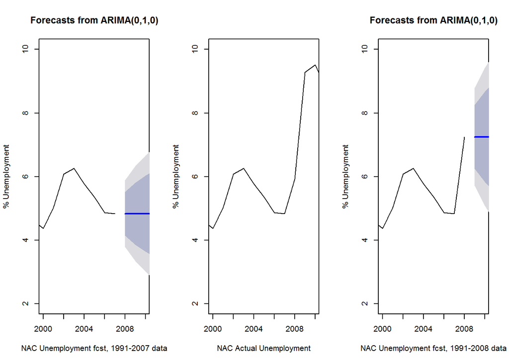

```r
trend.preds<-forecast.Arima(trends.arimausa,h=12)
plot.forecast(trend.preds, ylim = c(2,10), xlim = c(2000,2010),xlab="NAC Unemployment fcst, 1991-2008 data", ylab="% Unemployment")
```

```r
par(mfrow=c(1,3))
#EU unemployment forecast vs actual, 2000-2007
#needs work
trends.eu <-region_data %>% select(Year,Unemployment.Rate,Country.Code) %>% filter(Country.Code == "EUU")
trendsts.eu <- ts(as.vector(trends.eu$Unemployment.Rate),start = c(1991,1), end = c(2014), frequency = 1)

trends.eubc <- region_data  %>% select(Year,Unemployment.Rate,Country.Code) %>% filter(Country.Code == "EUU" & Year >=1991 & Year<=2007)
trendsts.eubc <- ts(as.vector(trends.eubc$Unemployment.Rate),start = c(1991,1), end = c(2007), frequency = 1)

trends.euac <- region_data  %>% select(Year,Unemployment.Rate,Country.Code) %>% filter(Country.Code == "EUU" & Year >=1991 & Year<=2008)
trendsts.euac <- ts(as.vector(trends.euac$Unemployment.Rate),start = c(1991,1), end = c(2008), frequency = 1)

trends.arimaeu<- auto.arima(trendsts.eubc, seasonal = FALSE)
trends.arimaeu
```

```
## Series: trendsts.eubc
## ARIMA(0,2,0)
##
## sigma^2 estimated as 0.3111:  log likelihood=-12.53
## AIC=27.05   AICc=27.36   BIC=27.76
```

```r
trend.preds<-forecast.Arima(trends.arimaeu,h=12)
plot.forecast(trend.preds, ylim = c(2,10), xlim = c(2000,2010),xlab="EUU unemployment forecast, 1991-2007 data",ylab="% Unemployment")

summary(trend.preds)
```

```
##
## Forecast method: ARIMA(0,2,0)
##
## Model Information:
## Series: trendsts.eubc
## ARIMA(0,2,0)
##
## sigma^2 estimated as 0.3111:  log likelihood=-12.53
## AIC=27.05   AICc=27.36   BIC=27.76
##
## Error measures:
##                       ME      RMSE       MAE       MPE     MAPE      MASE
## Training set -0.09969638 0.5239044 0.4165437 -1.078875 4.282199 0.8663989
##                    ACF1
## Training set -0.2083983
##
## Forecasts:
##      Point Forecast       Lo 80     Hi 80        Lo 95     Hi 95
## 2008      6.1291757   5.4144047  6.843947   5.03602777  7.222324
## 2009      5.0829164   3.4846398  6.681193   2.63856328  7.527269
## 2010      4.0366570   1.3622288  6.711085  -0.05352801  8.126842
## 2011      2.9903977  -0.9245644  6.905360  -2.99702013  8.977815
## 2012      1.9441383  -3.3567454  7.245022  -6.16286370 10.051140
## 2013      0.8978790  -5.9206019  7.716360  -9.53008765 11.325846
## 2014     -0.1483804  -8.6056650  8.308904 -13.08268109 12.785920
## 2015     -1.1946397 -11.4036118  9.014332 -16.80791510 14.418636
## 2016     -2.2408991 -14.3076226  9.825824 -20.69536010 16.213562
## 2017     -3.2871584 -17.3119784 10.737662 -24.73626961 18.161953
## 2018     -4.3334178 -20.4117941 11.744958 -28.92317235 20.256337
## 2019     -5.3796771 -23.6028338 12.843480 -33.24959019 22.490236
```

```r
plot(trendsts.eu, ylim = c(2,10), xlim = c(2000,2010), xlab="EUU Actual Unemployment",ylab="% Unemployment")

trends.arimaeu<- auto.arima(trendsts.euac,seasonal = FALSE)
trends.arimaeu
```

```
## Series: trendsts.euac
## ARIMA(0,2,0)
##
## sigma^2 estimated as 0.336:  log likelihood=-13.98
## AIC=29.96   AICc=30.24   BIC=30.73
```

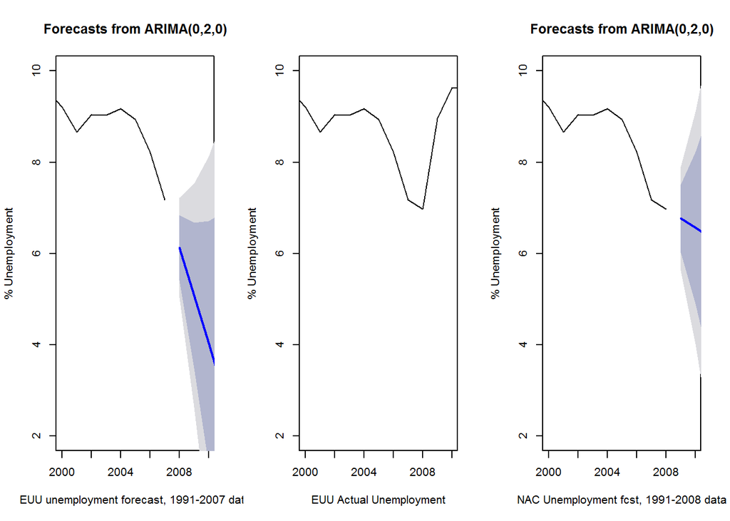

```r
trend.preds<-forecast.Arima(trends.arimaeu,h=12)
plot.forecast(trend.preds, ylim = c(2,10), xlim = c(2000,2010),xlab="NAC Unemployment fcst, 1991-2008 data", ylab="% Unemployment")
```

```r
par(mfrow=c(1,3))
#SAS unemployment forecast vs actual, 2000-2007
trends.sas <-region_data %>% select(Year,Unemployment.Rate,Country.Code) %>% filter(Country.Code == "SAS")
trendsts.sas <- ts(as.vector(trends.sas$Unemployment.Rate),start = c(1991,1), end = c(2014), frequency = 1)

trends.sasbc <- region_data  %>% select(Year,Unemployment.Rate,Country.Code) %>% filter(Country.Code == "SAS" & Year >=1991 & Year<=2007)
trendsts.sasbc <- ts(as.vector(trends.sasbc$Unemployment.Rate),start = c(1991,1), end = c(2007), frequency = 1)

trends.sasac <- region_data  %>% select(Year,Unemployment.Rate,Country.Code) %>% filter(Country.Code == "SAS" & Year >=1991 & Year<=2008)
trendsts.sasac <- ts(as.vector(trends.sasac$Unemployment.Rate),start = c(1991,1), end = c(2008), frequency = 1)

trends.arimasas<- auto.arima(trendsts.sasbc)
trend.preds<-forecast.Arima(trends.arimasas,h=12)
plot.forecast(trend.preds, ylim = c(2,10), xlim = c(2000,2010),xlab="SAS unemployment forecast, 1991-2007 data",ylab="% Unemployment")

summary(trend.preds)
```

```
##
## Forecast method: ARIMA(0,0,0) with non-zero mean
##
## Model Information:
## Series: trendsts.sasbc
## ARIMA(0,0,0) with non-zero mean
##
## Coefficients:
##         mean
##       4.2916
## s.e.  0.0517
##
## sigma^2 estimated as 0.04832:  log likelihood=2.15
## AIC=-0.29   AICc=0.56   BIC=1.37
##
## Error measures:
##                        ME      RMSE       MAE       MPE     MAPE      MASE
## Training set -7.83639e-17 0.2132614 0.1642265 -0.255086 3.890804 0.7797793
##                   ACF1
## Training set 0.1868108
##
## Forecasts:
##      Point Forecast    Lo 80    Hi 80    Lo 95    Hi 95
## 2008       4.291578 4.009861 4.573295 3.860729 4.722427
## 2009       4.291578 4.009861 4.573295 3.860729 4.722427
## 2010       4.291578 4.009861 4.573295 3.860729 4.722427
## 2011       4.291578 4.009861 4.573295 3.860729 4.722427
## 2012       4.291578 4.009861 4.573295 3.860729 4.722427
## 2013       4.291578 4.009861 4.573295 3.860729 4.722427
## 2014       4.291578 4.009861 4.573295 3.860729 4.722427
## 2015       4.291578 4.009861 4.573295 3.860729 4.722427
## 2016       4.291578 4.009861 4.573295 3.860729 4.722427
## 2017       4.291578 4.009861 4.573295 3.860729 4.722427
## 2018       4.291578 4.009861 4.573295 3.860729 4.722427
## 2019       4.291578 4.009861 4.573295 3.860729 4.722427
```

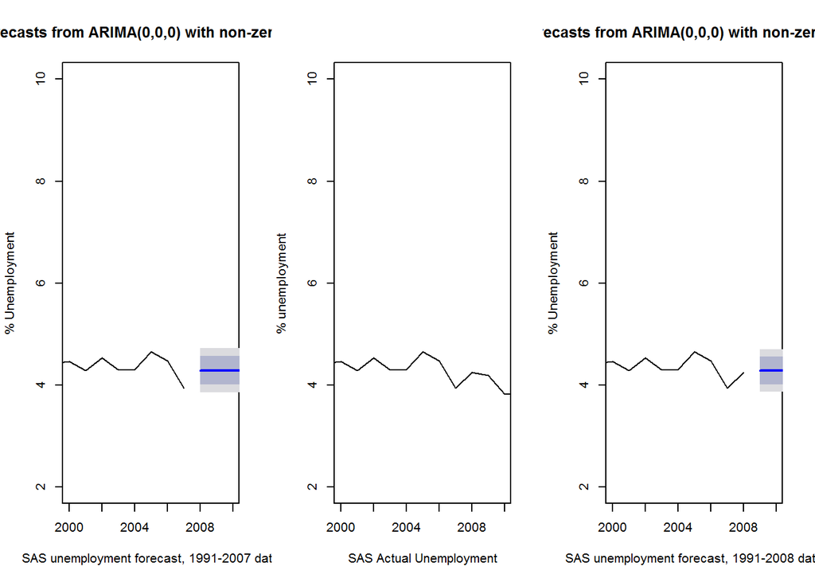

```r
plot(trendsts.sas, ylim = c(2,10), xlim = c(2000,2010), xlab="SAS Actual Unemployment",ylab="% unemployment")

trends.arimasas<- auto.arima(trendsts.sasac)
trend.preds<-forecast.Arima(trends.arimasas,h=12)
plot.forecast(trend.preds, ylim = c(2,10), xlim = c(2000,2010),xlab="SAS unemployment forecast, 1991-2008 data",ylab="% Unemployment")
```

```r
#manufacturing rate US region
par(mfrow=c(1,3))
trends.usa <-region_data %>% select(Year,Manufacturing.Rate,Country.Code) %>% filter(Country.Code == "NAC")
trendsts.usa <- ts(as.vector(trends.usa$Manufacturing.Rate),start = c(1991,1), end = c(2014), frequency = 1)

trends.usabc <- region_data  %>% select(Year,Manufacturing.Rate,Country.Code) %>% filter(Country.Code == "NAC" & Year >=1991 & Year<=2007)
trendsts.usabc <- ts(as.vector(trends.usabc$Manufacturing.Rate),start = c(1991,1), end = c(2007), frequency = 1)

trends.usaac <- region_data  %>% select(Year,Manufacturing.Rate,Country.Code) %>% filter(Country.Code == "NAC" & Year >=1991 & Year<=2008)
trendsts.usaac <- ts(as.vector(trends.usaac$Manufacturing.Rate),start = c(1991,1), end = c(2008), frequency = 1)

trends.arimausa<- auto.arima(trendsts.usabc)
trend.preds<-forecast.Arima(trends.arimausa,h=12)
plot.forecast(trend.preds, ylim = c(10,18), xlim = c(2000,2010), xlab="NAC mfg forecast, 1991-2007 data", ylab="rate")

summary(trend.preds)
```

```
##
## Forecast method: ARIMA(0,1,0) with drift
##
## Model Information:
## Series: trendsts.usabc
## ARIMA(0,1,0) with drift
##
## Coefficients:
##         drift
##       -0.3463
## s.e.   0.1083
##
## sigma^2 estimated as 0.07817:  log likelihood=-3.47
## AIC=10.94   AICc=11.86   BIC=12.49
##
## Error measures:
##                       ME      RMSE       MAE        MPE     MAPE      MASE
## Training set 0.001727376 0.3264833 0.2041199 0.05266215 1.477677 0.5825066
##                  ACF1
## Training set 0.267535
##
## Forecasts:
##      Point Forecast     Lo 80    Hi 80     Lo 95    Hi 95
## 2008      12.768023 12.409722 13.12632 12.220049 13.31600
## 2009      12.421735 11.915021 12.92845 11.646783 13.19669
## 2010      12.075448 11.454852 12.69604 11.126329 13.02457
## 2011      11.729160 11.012558 12.44576 10.633212 12.82511
## 2012      11.382873 10.581688 12.18406 10.157566 12.60818
## 2013      11.036585 10.158931 11.91424  9.694329 12.37884
## 2014      10.690298  9.742323 11.63827  9.240495 12.14010
## 2015      10.344010  9.330582 11.35744  8.794106 11.89391
## 2016       9.997723  8.922820 11.07263  8.353801 11.64164
## 2017       9.651435  8.518388 10.78448  7.918590 11.38428
## 2018       9.305148  8.116798 10.49350  7.487724 11.12257
## 2019       8.958860  7.717670 10.20005  7.060623 10.85710
```

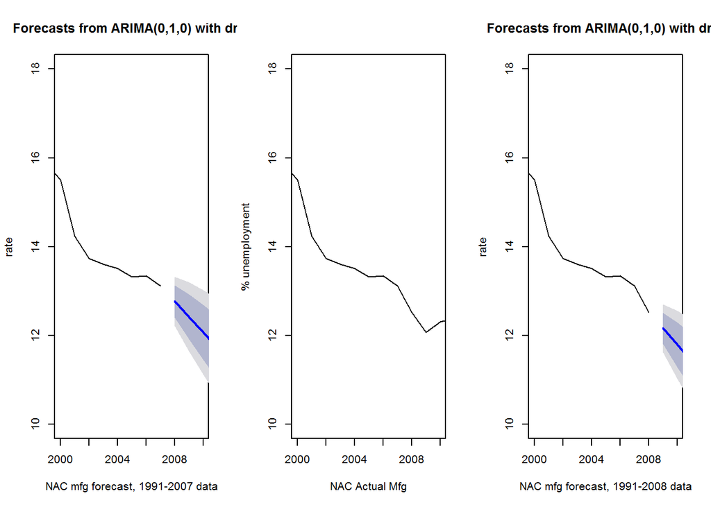

```r
plot(trendsts.usa, ylim = c(10,18), xlim = c(2000,2010), xlab="NAC Actual Mfg",ylab="% unemployment")

trends.arimausa<- auto.arima(trendsts.usaac)
trend.preds<-forecast.Arima(trends.arimausa,h=12)
plot.forecast(trend.preds, ylim = c(10,18), xlim = c(2000,2010), xlab="NAC mfg forecast, 1991-2008 data", ylab="rate")
```

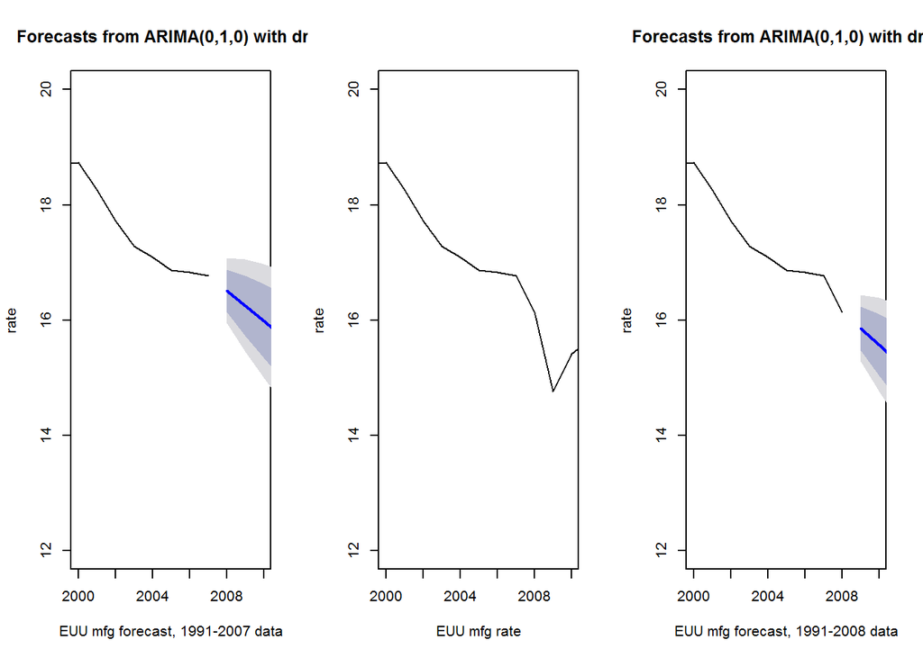

```r
par(mfrow=c(1,3))
#manufacturing rate EUU region
trends.euu <-region_data %>% select(Year,Manufacturing.Rate,Country.Code) %>% filter(Country.Code == "EUU")
trendsts.euu <- ts(as.vector(trends.euu$Manufacturing.Rate),start = c(1991,1), end = c(2014), frequency = 1)

trends.eubc <- region_data  %>% select(Year,Manufacturing.Rate,Country.Code) %>% filter(Country.Code == "EUU" & Year >=1991 & Year<=2007)
trendsts.eubc <- ts(as.vector(trends.eubc$Manufacturing.Rate),start = c(1991,1), end = c(2007), frequency = 1)

trends.euac <- region_data  %>% select(Year,Manufacturing.Rate,Country.Code) %>% filter(Country.Code == "EUU" & Year >=1991 & Year<=2008)
trendsts.euac <- ts(as.vector(trends.euac$Manufacturing.Rate),start = c(1991,1), end = c(2008), frequency = 1)

trends.arimaeu<- auto.arima(trendsts.eubc)
trend.preds<-forecast.Arima(trends.arimaeu,h=12)
plot.forecast(trend.preds, ylim = c(12,20), xlim = c(2000,2010), xlab="EUU mfg forecast, 1991-2007 data", ylab="rate")

plot(trendsts.euu,ylim = c(12,20), xlim = c(2000,2010),xlab="EUU mfg rate", ylab="rate")

trends.arimaeu<- auto.arima(trendsts.euac)
trend.preds<-forecast.Arima(trends.arimaeu,h=12)
plot.forecast(trend.preds, ylim = c(12,20),xlim = c(2000,2010), xlab="EUU mfg forecast, 1991-2008 data", ylab="rate")
```

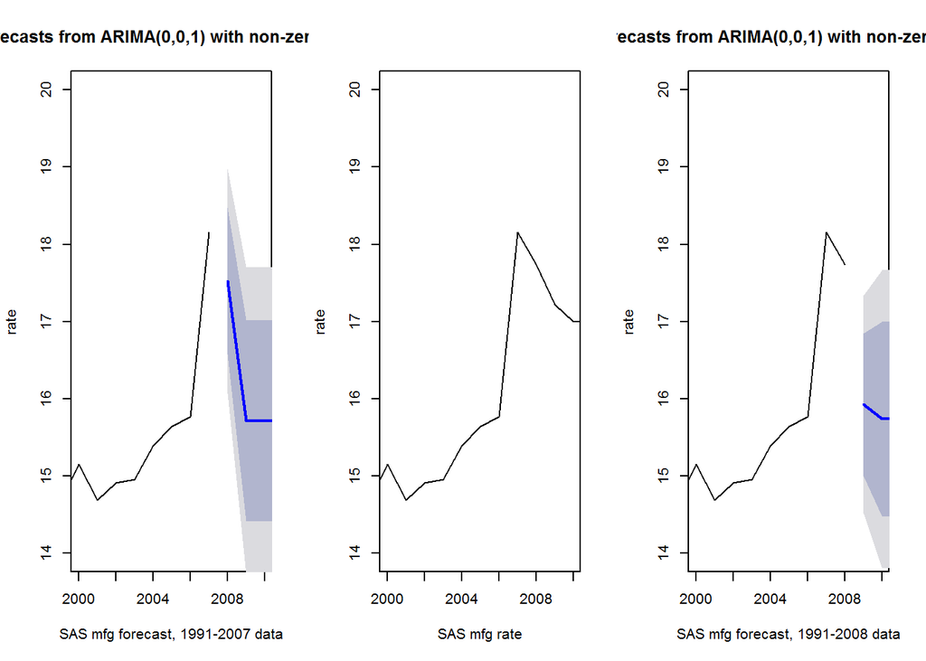

```r
par(mfrow=c(1,3))
#manufacturing rate SAS region
trends.sas <-region_data %>% select(Year,Manufacturing.Rate,Country.Code) %>% filter(Country.Code == "SAS")
trendsts.sas <- ts(as.vector(trends.sas$Manufacturing.Rate),start = c(1991,1), end = c(2014), frequency = 1)

trends.sasbc <- region_data  %>% select(Year,Manufacturing.Rate,Country.Code) %>% filter(Country.Code == "SAS" & Year >=1991 & Year<=2007)
trendsts.sasbc <- ts(as.vector(trends.sasbc$Manufacturing.Rate),start = c(1991,1), end = c(2007), frequency = 1)

trends.sasac <- region_data  %>% select(Year,Manufacturing.Rate,Country.Code) %>% filter(Country.Code == "SAS" & Year >=1991 & Year<=2008)
trendsts.sasac <- ts(as.vector(trends.sasac$Manufacturing.Rate),start = c(1991,1), end = c(2008), frequency = 1)

trends.arimasas<- auto.arima(trendsts.sasbc)
trend.preds<-forecast.Arima(trends.arimasas,h=12)
plot.forecast(trend.preds, ylim = c(14,20), xlim = c(2000,2010), xlab="SAS mfg forecast, 1991-2007 data", ylab="rate")

plot(trendsts.sas,ylim = c(14,20),xlim = c(2000,2010),xlab="SAS mfg rate", ylab="rate")

trends.arimasas<- auto.arima(trendsts.sasac)
trend.preds<-forecast.Arima(trends.arimasas,h=12)
plot.forecast(trend.preds,  ylim = c(14,20),xlim = c(2000,2010), xlab="SAS mfg forecast, 1991-2008 data", ylab="rate")
```

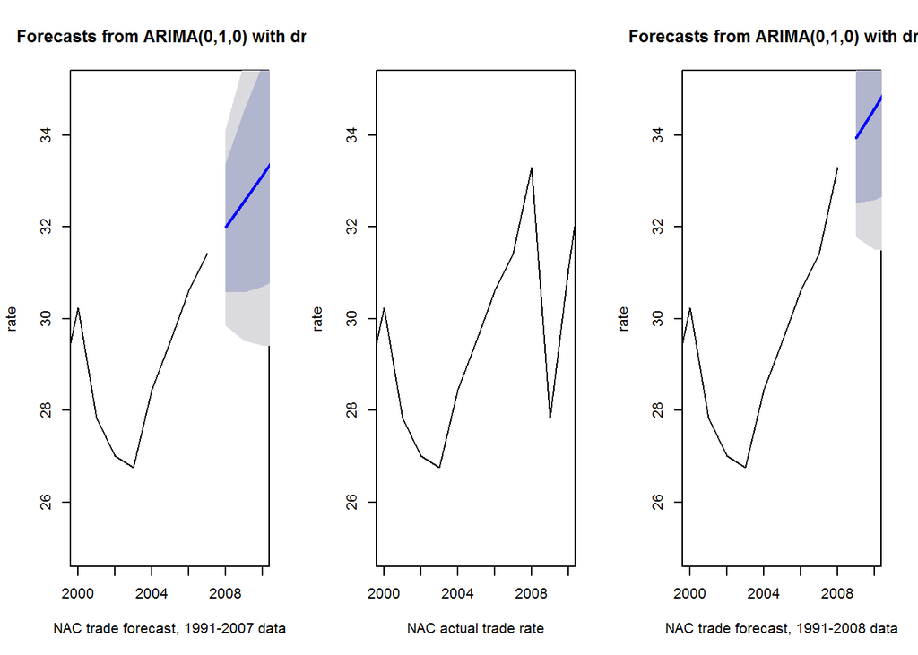

```r
par(mfrow=c(1,3))
#US trade
trends.usa <-region_data %>% select(Year,Trade,Country.Code) %>% filter(Country.Code == "NAC")
trendsts.usa <- ts(as.vector(trends.usa$Trade),start = c(1991,1), end = c(2014), frequency = 1)

trends.usabc <- region_data  %>% select(Year,Trade,Country.Code) %>% filter(Country.Code == "NAC" & Year >=1991 & Year<=2007)
trendsts.usabc <- ts(as.vector(trends.usabc$Trade),start = c(1991,1), end = c(2007), frequency = 1)

trends.usaac <- region_data  %>% select(Year,Trade,Country.Code) %>% filter(Country.Code == "NAC" & Year >=1991 & Year<=2008)
trendsts.usaac <- ts(as.vector(trends.usaac$Trade),start = c(1991,1), end = c(2008), frequency = 1)

trends.arimausa<- auto.arima(trendsts.usabc)
trend.preds<-forecast.Arima(trends.arimausa,h=12)
plot.forecast(trend.preds, ylim = c(25,35),xlim = c(2000,2010),xlab="NAC trade forecast, 1991-2007 data", ylab="rate")

plot(trendsts.usa,  ylim = c(25,35),xlim = c(2000,2010),xlab="NAC actual trade rate", ylab="rate")

trends.arimausa<- auto.arima(trendsts.usaac)
trend.preds<-forecast.Arima(trends.arimausa,h=12)
plot.forecast(trend.preds,ylim = c(25,35), xlim = c(2000,2010),xlab="NAC trade forecast, 1991-2008 data", ylab="rate")
```

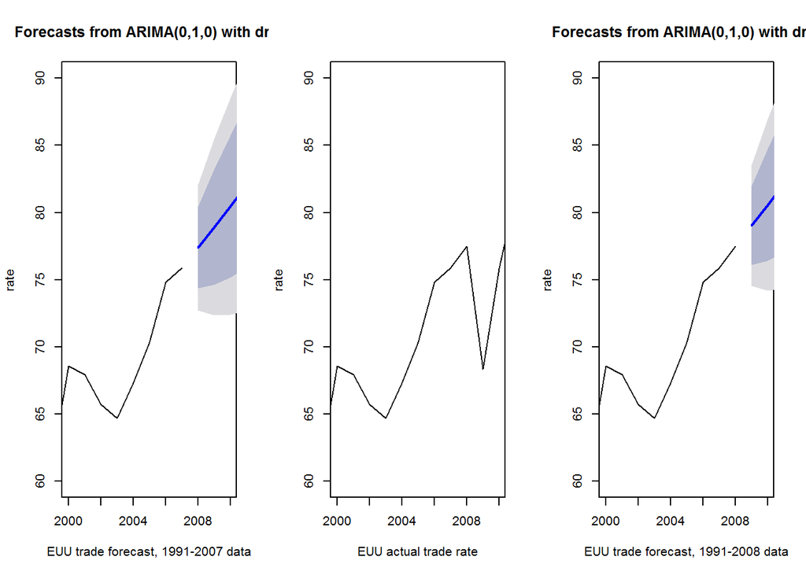

```r
par(mfrow=c(1,3))
#EU trade
trends.eu <-region_data %>% select(Year,Trade,Country.Code) %>% filter(Country.Code == "EUU")
trendsts.eu <- ts(as.vector(trends.eu$Trade),start = c(1991,1), end = c(2014), frequency = 1)

trends.eubc <- region_data  %>% select(Year,Trade,Country.Code) %>% filter(Country.Code == "EUU" & Year >=1991 & Year<=2007)
trendsts.eubc <- ts(as.vector(trends.eubc$Trade),start = c(1991,1), end = c(2007), frequency = 1)

trends.euac <- region_data  %>% select(Year,Trade,Country.Code) %>% filter(Country.Code == "EUU" & Year >=1991 & Year<=2008)
trendsts.euac <- ts(as.vector(trends.euac$Trade),start = c(1991,1), end = c(2008), frequency = 1)

trends.arimaeu<- auto.arima(trendsts.eubc)
trend.preds<-forecast.Arima(trends.arimaeu,h=12)
plot.forecast(trend.preds,ylim = c(60,90), xlim = c(2000,2010),xlab="EUU trade forecast, 1991-2007 data", ylab="rate")

plot(trendsts.eu, ylim = c(60,90), xlim = c(2000,2010),xlab="EUU actual trade rate", ylab="rate")

trends.arimaeu<- auto.arima(trendsts.euac)
trend.preds<-forecast.Arima(trends.arimaeu,h=12)
plot.forecast(trend.preds, ylim = c(60,90),xlim = c(2000,2010),xlab="EUU trade forecast, 1991-2008 data", ylab="rate")
```

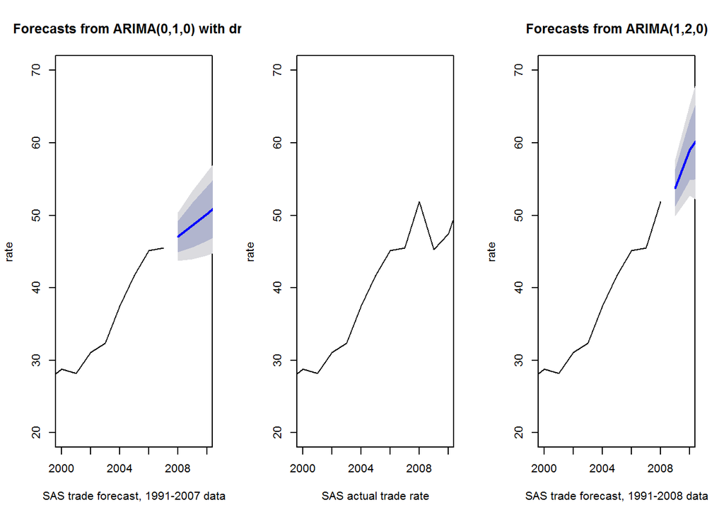

```r
par(mfrow=c(1,3))
#SAS trade
trends.sas <-region_data %>% select(Year,Trade,Country.Code) %>% filter(Country.Code == "SAS")
trendsts.sas <- ts(as.vector(trends.sas$Trade),start = c(1991,1), end = c(2014), frequency = 1)

trends.sasbc <- region_data  %>% select(Year,Trade,Country.Code) %>% filter(Country.Code == "SAS" & Year >=1991 & Year<=2007)
trendsts.sasbc <- ts(as.vector(trends.sasbc$Trade),start = c(1991,1), end = c(2007), frequency = 1)

trends.sasac <- region_data  %>% select(Year,Trade,Country.Code) %>% filter(Country.Code == "SAS" & Year >=1991 & Year<=2008)
trendsts.sasac <- ts(as.vector(trends.sasac$Trade),start = c(1991,1), end = c(2008), frequency = 1)

trends.arimasas<- auto.arima(trendsts.sasbc)
trend.preds<-forecast.Arima(trends.arimasas,h=12)
plot.forecast(trend.preds,ylim = c(20,70), xlim = c(2000,2010),xlab="SAS trade forecast, 1991-2007 data", ylab="rate")

plot(trendsts.sas,ylim = c(20,70),xlim = c(2000,2010),xlab="SAS actual trade rate", ylab="rate")

trends.arimasas<- auto.arima(trendsts.sasac)
trend.preds<-forecast.Arima(trends.arimasas,h=12)
plot.forecast(trend.preds, ylim = c(20,70),xlim = c(2000,2010),xlab="SAS trade forecast, 1991-2008 data", ylab="rate")
```

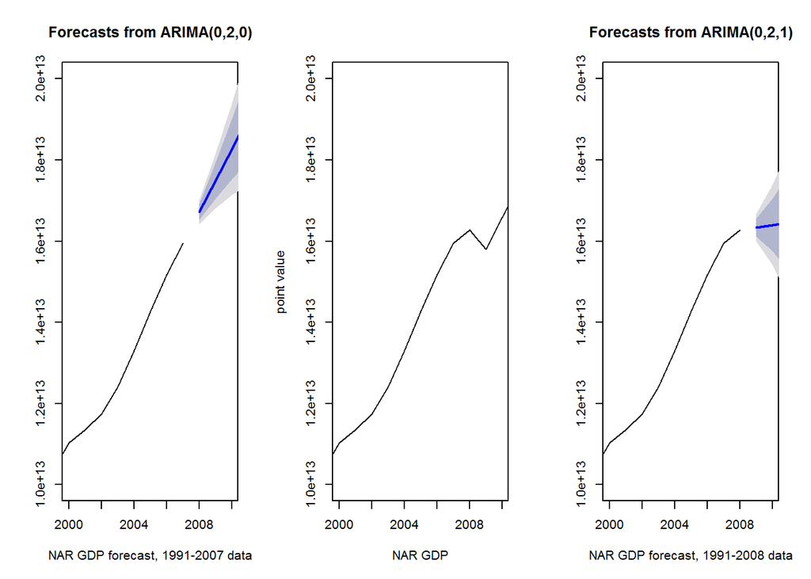

```r
par(mfrow=c(1,3))
#US GDP
trends.usa <-region_data %>% select(Year,GDP,Country.Code) %>% filter(Country.Code == "NAC")
trendsts.usa <- ts(as.vector(trends.usa$GDP),start = c(1991,1), end = c(2014), frequency = 1)

trends.usabc <- region_data  %>% select(Year,GDP,Country.Code) %>% filter(Country.Code == "NAC" & Year >=1991 & Year<=2007)
trendsts.usabc <- ts(as.vector(trends.usabc$GDP),start = c(1991,1), end = c(2007), frequency = 1)

trends.usaac <- region_data  %>% select(Year,GDP,Country.Code) %>% filter(Country.Code == "NAC" & Year >=1991 & Year<=2008)
trendsts.usaac <- ts(as.vector(trends.usaac$GDP),start = c(1991,1), end = c(2008), frequency = 1)

trends.arimausa<- auto.arima(trendsts.usabc)
trend.preds<-forecast.Arima(trends.arimausa,h=12)
plot.forecast(trend.preds,ylim = c(1.0e+13,2.0e+13), xlim = c(2000,2010), xlab="NAR GDP forecast, 1991-2007 data")

plot(trendsts.usa , ylim = c(1.0e+13,2.0e+13), xlim = c(2000,2010),xlab="NAR GDP", ylab ="point value")

trends.arimausa<- auto.arima(trendsts.usaac)
trend.preds<-forecast.Arima(trends.arimausa,h=12)
plot.forecast(trend.preds, ylim = c(1.0e+13,2.0e+13),xlim = c(2000,2010), xlab="NAR GDP forecast, 1991-2008 data")
```

[figure not shown]

```r
par(mfrow=c(1,3))
#EUU GDP
trends.eu <-region_data %>% select(Year,GDP,Country.Code) %>% filter(Country.Code == "EUU")
trendsts.eu <- ts(as.vector(trends.eu$GDP),start = c(1991,1), end = c(2014), frequency = 1)

trends.eubc <- region_data  %>% select(Year,GDP,Country.Code) %>% filter(Country.Code == "EUU" & Year >=1991 & Year<=2007)
trendsts.eubc <- ts(as.vector(trends.eubc$GDP),start = c(1991,1), end = c(2007), frequency = 1)

trends.euac <- region_data  %>% select(Year,GDP,Country.Code) %>% filter(Country.Code == "EUU" & Year >=1991 & Year<=2008)
trendsts.euac <- ts(as.vector(trends.eubc$GDP),start = c(1991,1), end = c(2008), frequency = 1)

trends.arimaeu<- auto.arima(trendsts.eubc)
trend.preds<-forecast.Arima(trends.arimaeu,h=12)
plot.forecast(trend.preds, ylim=c(8e+12,2.5e+13),xlim = c(2000,2010), xlab="EU GDP forecast, 1991-2007 data")

plot(trendsts.eu , ylim=c(8e+12,2.5e+13), xlim = c(2000,2010),xlab="EU GDP")

trends.arimaeu<- auto.arima(trendsts.euac)
trend.preds<-forecast.Arima(trends.arimaeu,h=12)
plot.forecast(trend.preds, ylim=c(8e+12,2.5e+13),xlim = c(2000,2010), xlab="EU GDP forecast, 1991-2008 data")
```

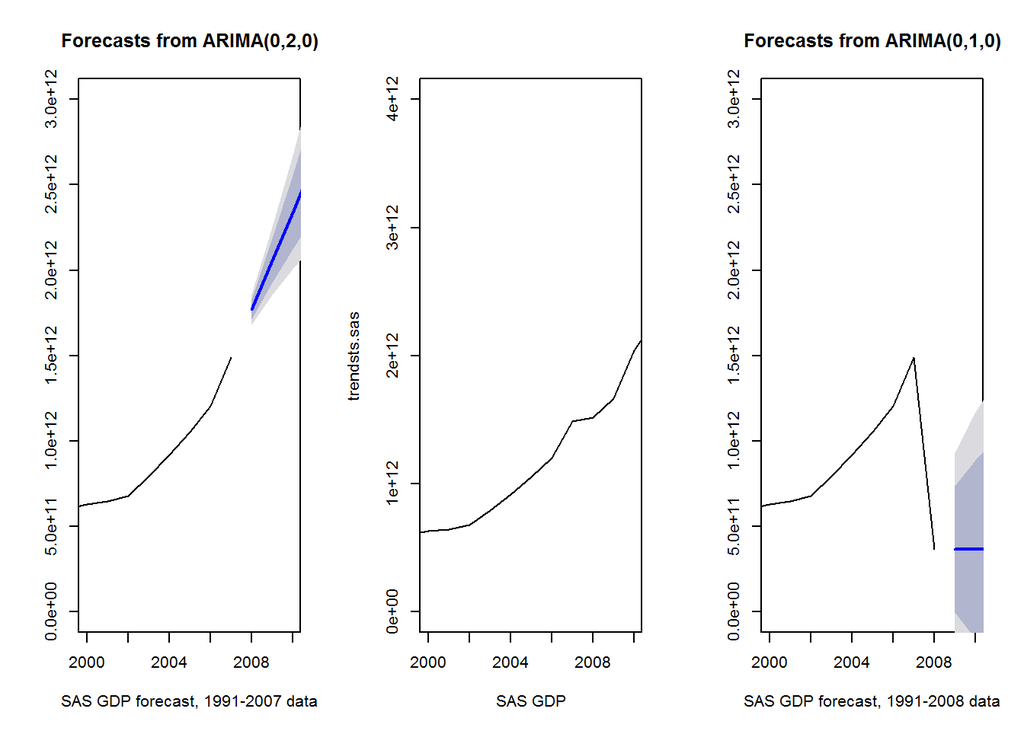

```r
par(mfrow=c(1,3))
#SAS GDP
trends.sas <-region_data %>% select(Year,GDP,Country.Code) %>% filter(Country.Code == "SAS")
trendsts.sas <- ts(as.vector(trends.sas$GDP),start = c(1991,1), end = c(2014), frequency = 1)

trends.sasbc <- region_data  %>% select(Year,GDP,Country.Code) %>% filter(Country.Code == "SAS" & Year >=1991 & Year<=2007)
trendsts.sasbc <- ts(as.vector(trends.sasbc$GDP),start = c(1991,1), end = c(2007), frequency = 1)

trends.sasac <- region_data  %>% select(Year,GDP,Country.Code) %>% filter(Country.Code == "SAS" & Year >=1991 & Year<=2008)
trendsts.sasac <- ts(as.vector(trends.sasbc$GDP),start = c(1991,1), end = c(2008), frequency = 1)

trends.arimasas<- auto.arima(trendsts.sasbc)
trend.preds<-forecast.Arima(trends.arimasas,h=12)
plot.forecast(trend.preds,ylim = c(0e+12, 3e+12),xlim = c(2000,2010), xlab="SAS GDP forecast, 1991-2007 data")

plot(trendsts.sas ,ylim = c(0e+12, 4e+12) ,xlim = c(2000,2010),xlab="SAS GDP")

trends.arimasas<- auto.arima(trendsts.sasac)
trend.preds<-forecast.Arima(trends.arimasas,h=12)
plot.forecast(trend.preds,ylim = c(0e+12, 3e+12),xlim = c(2000,2010), xlab="SAS GDP forecast, 1991-2008 data")
```

CPI data was unavailable at region-level. So we could not perform time series analysis for CPI.